# Marketing Insight Report - Facebook Metrics

Etini Akpayang

2025-01-30

## Loading Libraries

# Introduction

**Task: Facebook Metrics Analysis**

This task involves analyzing Facebook post engagement data to identify trends and insights. Key steps include data cleaning, exploratory data analysis, and visualization of engagement metrics like likes, comments, and shares. The goal is to determine the best posting times, post types, and the impact of paid versus organic reach.

We will briefly attempt to get key marketable metrics from this the facebook data to aid the marketing department develop data driven strategies going forward.

# The Dataset

## Data Loading, Viewing, and Structure Understanding

The dataset contains Facebook post-performance metrics, including details on post type, posting time, and engagement levels. It includes variables like likes, comments, shares, and total interactions, along with paid and organic reach. The data allows for analyzing engagement trends across different post attributes.

At this stage, we are focusing on **likes, comments, shares, total interactions, post type, posting time, and paid vs. organic performance**.

## Data Cleaning

Data cleaning involved renaming columns for consistency and converting categorical variables like **post type**, **weekday**, and **paid status** into factors for easier analysis. Missing values were checked and removed to ensure accurate insights.

## Key Engagement Insights

We analyzed key engagement metrics, including **likes, comments, and shares,** to understand overall audience interaction. Averages were computed to provide a baseline for post performance.

```r
engagement_summary <- fb_data %>%
  summarise(
    avg_like = mean(like, na.rm = TRUE),
    avg_comments = mean(comment, na.rm = TRUE),
    avg_shares = mean(share, na.rm = TRUE)
  )
engagement_summary
```

```
##   avg_like avg_comments avg_shares
## 1 179.1455     7.557576   27.26465
```

## Top Performing Posts

The highest-performing posts were identified based on **like counts**, with additional insights from **comments**, **shares**, and **posting time**. These posts reveal content types and timing that drive the most engagement.

```r
top_posts <- fb_data %>%
  arrange(desc(like)) %>%
  select(Type, like, comment, share, Post_Hour, Post_Month, Post_Weekday) %>%
  head(10)
top_posts
```

```
##     Type like comment share Post_Hour Post_Month Post_Weekday
## 1  Photo 5172     372   790         5        Jul          Tue
## 2  Photo 1998      51   128        14        Apr          Sun
## 3  Photo 1639      45   122        13        May          Thu
## 4  Photo 1622     144   208        10        Sep          Tue
## 5  Photo 1572      58   147        10        Dec          Mon
## 6  Photo 1546     146   181        13        Feb          Sun
## 7  Photo 1505      26    95         3        Oct          Wed
## 8  Photo 1372      20    47        10        Jun          Sun
## 9  Photo 1155      33   102        10        Aug          Wed
## 10 Photo 1047      29    98         3        Sep          Fri
```

## Engagement by Post Type

Posts were grouped by **type** (e.g., photo, video, status) to compare average interactions. This helps determine which content format resonates most with the audience.

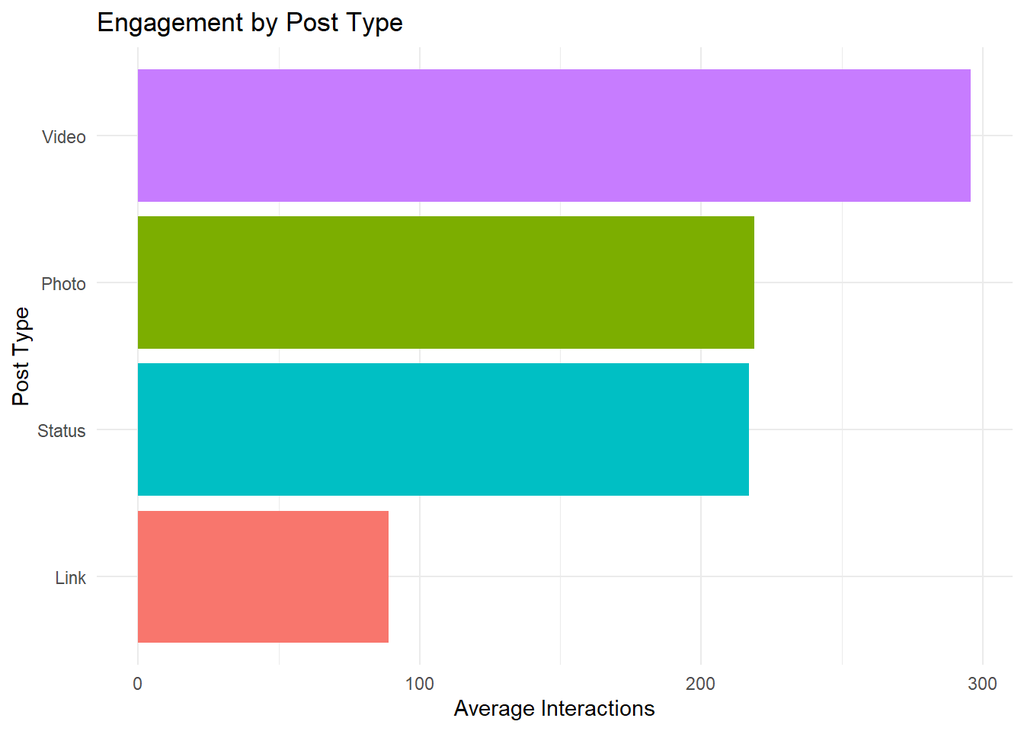

```r
fb_data %>%
  group_by(Type) %>%
  summarise(Avg_Interactions = mean(Total_Interactions, na.rm = TRUE)) %>%
  ggplot(aes(x = reorder(Type, Avg_Interactions), y = Avg_Interactions, fill = Type)) +
  geom_col(show.legend = FALSE) +
  coord_flip() +
  labs(title = "Engagement by Post Type", x = "Post Type", y = "Average Interactions") +
  theme_minimal()
```

## Best Posting Time for Engagement

Engagement levels were analyzed across different **posting hours** to identify peak activity periods. This insight helps optimize posting schedules for maximum reach.

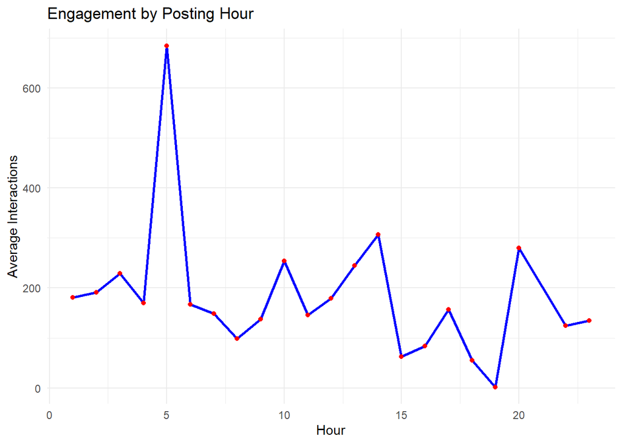

```r
fb_data %>%
  group_by(Post_Hour) %>%
  summarise(Avg_Interactions = mean(Total_Interactions, na.rm = TRUE)) %>%
  ggplot(aes(x = Post_Hour, y = Avg_Interactions)) +
  geom_line(color = "blue", size = 1) +
  geom_point(color = "red") +
  labs(title = "Engagement by Posting Hour", x = "Hour", y = "Average Interactions") +
  theme_minimal()
```

## Paid vs. Organic Performance

Posts were categorized into **paid and organic** to compare their reach and interactions. This analysis highlights the impact of paid promotions on engagement levels.

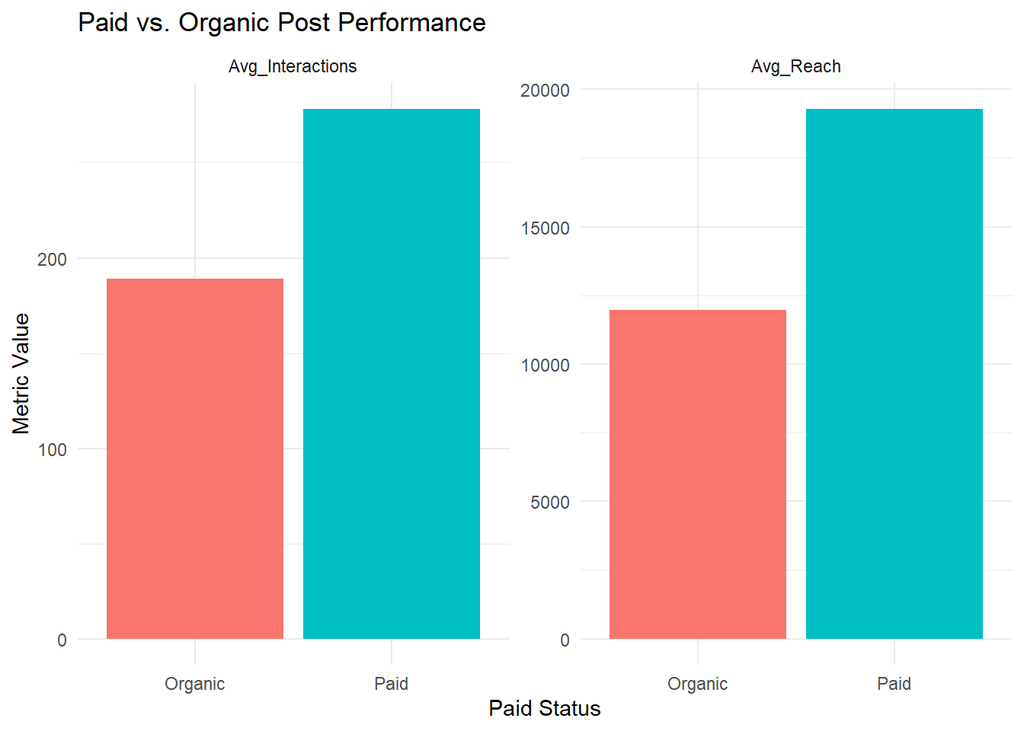

```r
fb_data %>%
  group_by(Paid) %>%
  summarise(Avg_Reach = mean(Lifetime_Post_Total_Reach, na.rm = TRUE),
            Avg_Interactions = mean(Total_Interactions, na.rm = TRUE)) %>%
  pivot_longer(cols = c(Avg_Reach, Avg_Interactions), names_to = "Metric", values_to = "Value") %>%
  ggplot(aes(x = Paid, y = Value, fill = Paid)) +
  geom_col(show.legend = FALSE) +
  facet_wrap(~ Metric, scales = "free") +
  theme_minimal() +
  labs(title = "Paid vs. Organic Post Performance", x = "Paid Status", y = "Metric Value")
```

## Conclusion

This report provides key insights into Facebook post performance, focusing on **top-performing posts, engagement trends, and paid vs. organic comparisons**. Videos consistently received the highest engagement though mostly as impression as photos had the most **likes** and **comments** in the **top performuing posts**, and paid posts outperformed organic ones. To improve interactions, video content should be prioritized, and links can be embedded instead of posted separately. Lastly, the **5th hour** emerged as the best time for engagement and should be leveraged.

## Recommendations

Further analysis can identify **specific audience segments** for better targeting and **optimal posting days and months** for engagement. A deeper look into seasonal trends could reveal additional insights.